# lecture-04-secondary-data

## M303 Secondary Data

[figure not shown]

FALL 2026 · LECTURE 04

M303

Secondary Data

Use existing evidence to sharpen the question before collecting anything new.

## Where we are

**FROM RESEARCH DESIGN TO DATA COLLECTION**Before collecting anything new, check whether existing evidence can answer—or sharpen—the research question.

02

01

**Use your name tag.**  
It helps everyone learn names and participate.

02

**Please put away phones, tablets, and laptops**  
unless I ask you to use them.

## Learning Objectives

01**Distinguish**

Secondary data and research from primary data and research.

02**Evaluate**

The benefits, limitations, and fit of secondary data.

03**Locate**

Internal and external sources of secondary data.

04**Compare**

Retail audits, consumer panels, scanner data, and single-source systems.

Problem formulationResearch designData collectionAnalysis & recommendation

## Prior-class review

01

When you have little prior knowledge of the problem, use **________** research.

**exploratory**

02

Methods that are unstructured and mostly qualitative are typical of **________** research.

**exploratory**

03

When hypotheses are well defined and specific, the research design is usually **________**.

**causal**

04

Research used to describe an existing situation is **________** research.

**descriptive**

05

“Half of Indianapolis residents drink beer weekly” is an example of **________** research.

**descriptive**

06

Questions such as what, who, where, when, and how are associated with **________** research.

**descriptive**

07

Research that can establish whether one variable causes another is **________** research.

**causal**

08

Experiments are the defining method for **________** research.

**causal**

09

Match the problem stage: ambiguous → ________; understood → ________; clearly defined causes → ________.

*exploratory**descriptive**causal*

## Primary vs. secondary research

Primary research

Secondary research

Original data collected…

By you—or a company you hire—for the current research question

By someone else, usually for another purpose

Examples

Surveys · focus groups · interviews · observation · experiments

Using existing internal records, published data, or standardized services

Qualitative or quantitative?

Can be either

Can be either

## Why use secondary data?

Start  
smarter

01

May be sufficient to solve the problem.

02

Clarifies the problem and supports hypotheses.

03

Improves the design of primary data collection.

04

Provides a benchmark for validating primary results.

## Examples: using secondary data

01**Understand an industry**

Establishments · revenue · employment · payroll per employee

02**Estimate demand**

Use sources such as the U.S. Census Bureau.

03**Select target markets**

Compare markets before investing in primary research.

04**Geocode opportunity**

Combine geography with demographic and psychographic information.

Example source · U.S. Census Bureau

## Pros and cons of secondary data

PROS

- Lower cost
- Less effort
- Faster access
- Sometimes more accurate
- Sometimes the only feasible source

CONS

- Collected for another purpose
- No control over collection
- May be inaccurate or outdated
- May use the wrong units or format
- May not meet the current requirements
- Often requires assumptions

Check: **who** collected it · **why** · **how** · **what** · **when** · whether sources are **consistent**

## Sources of secondary data

Secondary  
data

Internal sources

Customer databases  
Sales and patronage  
Marketing activity and cost  
Distributor and customer feedback

External sources

**Published data**  
Government · trade reports · books · news · annual reports

**Standardized sources**  
Audits · panels · scanners · single-source systems

## What is a customer database?

Raw customer information  
enhanced to create value

TransactionsInventoryFeedbackDemographicsPsychographics

**Historical source-deck claims**

94% of large U.S. companies had customer databases; Ford held 50 million records and Kraft Foods held 30 million names.

Illustrative legacy figures—not current estimates; the source deck did not supply publication dates.

## How to use customer databases

TRANSACTIONS

01

Understand customer preferences

02

Identify payment patterns

03

Analyze purchase behavior

04

Segment loyal, profitable, and loss-making customers

## Example: segmenting by CLV

Rank customers into deciles based on customer lifetime value (CLV).

1

2

3

4

5

6

7

8

9

10

High CLVMedium CLVLow CLV

## Example: customer profiles

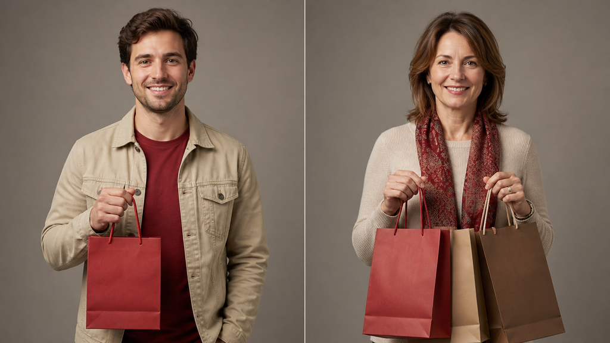

TYPICAL HIGH CLV CUSTOMER

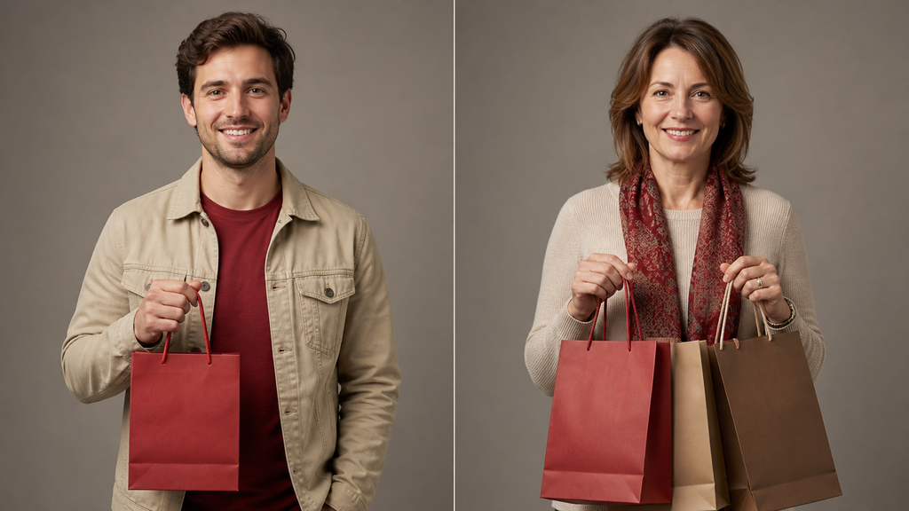

TYPICAL LOW CLV CUSTOMER

**Gender:** male  
**Age:** 25–34  
**Marital status:** single  
**Children:** none  
**Estimated household income:** below $50,000  
**Distance:** lives farther from the retailer  
**Loyalty card:** not necessarily a member  
**Channel:** single-channel shopper

## Example: holiday catalog targeting

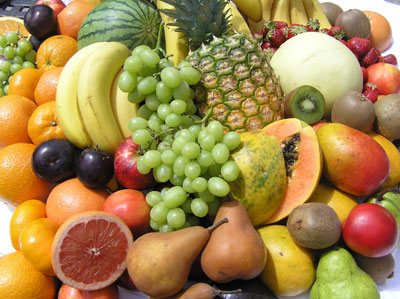

PROBLEM

Fruit-catalog company XYZ wants to know which customers should receive holiday gift cards.

Whom should the company target?

CUSTOMER DATABASE

Use prior customer records, including holiday-season purchases.

RECOMMENDATION

Prioritize customers who previously purchased during the holiday season.

## External sources of secondary data

01**Published data**

Sources created by governments, firms, associations, journalists, and scholars.

02**Standardized sources**

Data collected repeatedly through consistent procedures for multiple users.

Which source best fits the decision, time horizon, unit of analysis, and required detail?

## What is published data?

The most widely used source of secondary data

01

Readily available

02

Can answer part—or all—of the research question

03

Available in print or searchable digital databases

## Sources of published data

Federal governmentState and local governmentsStatistics agenciesBusiness publicationsNews articlesAnnual reportsAcademic publicationsLibrary databasesComputerized bibliographiesSyndicated services

[figure not shown]

[figure not shown]

## Standardized sources of secondary data

Data collected repeatedly using **standardized procedures**, usually for multiple subscribing users.

01

Retail store audits

02

Consumer panels

03

Scanner services

04

Single-source systems

## 1. Retail store audits

DATA COLLECTION

At regular intervals, auditors visit a sample of stores to count inventory and record deliveries since the previous visit.

Beginning inventory + deliveries − ending inventory = **movement through the store**

They can also record shelf prices, displays, shelf space, and in-store promotions.

Count**+**Deliveries**−**Inventory**=**Movement

## Historical example: Nielsen Retail Index

HISTORICAL SOURCE-DECK EXAMPLE

Nielsen’s auditing services were organized around four reporting groups:

Grocery productsDrugsOther merchandiseAlcoholic beverages

[figure not shown]

**Sales**Volume · trend · share**Distribution**% of stores · out-of-stocks**Selling prices**Volume at each price or deal**Retailer decisions**In-store promotions**Media advertising**Total category · major brands

## 2. Consumer purchase panels

STORE**SKU → SALE***aggregate movement*

**Store audit**

How much moved through stores?

Missing link

Who bought it?  
How often?  
Did they switch?

HOUSEHOLD**BUY → REBUY***behavior over time*

**Consumer panel**

Which households purchased—and how behavior changed over time.

## How are panel data collected?

01

**Home audit**

A panel member allows an auditor to check household stocks in selected categories at regular intervals.

Historically required households to retain packages and wrappers.

02

**Purchase diary**

A panel member records purchase details and submits the diary at regular intervals.

Traditionally returned by mail; the underlying method can now be digital.

## Benefits of consumer panels

MARKET SNAPSHOT

Aggregate sales activityBrand shares

PURCHASE HISTORY

Heavy buyersBrand-switching ratesCumulative market penetrationTrial and repeat purchase

## Limitations of consumer panels

01**Selection bias**

High refusal rates and incomplete population coverage.

02**Panel mortality**

Members drop out over time; the source deck cited annual dropout above 20% as a historical example.

03**Testing effects**

New members may report unusual purchasing because they know they are being observed.

04**Missing purchases**

One household reporter may overlook purchases made by other members.

## 3. Scanner data

[figure not shown]

Universal Product Code (UPC) systems record transactions at checkout.

They connect individual-household purchasing behavior and marketing activity to sales and revenue.

Product purchasing recordsProduct priceCoupon responseShelf space and displaysMarket and brand advertising

## Benefits of scanner data

◎**High accuracy**

Transactions are captured at the point of sale.

◷**Time savings**

Data can be available faster than periodic audits.

↺**Short-interval analysis**

Study demand and marketing activity week by week—or even more frequently.

## Historical example: P&G and Walmart

HISTORICAL RETAIL-ANALYTICS EXAMPLE

What should Walmart stock before a hurricane?

The source deck reports that strawberry Pop-Tarts sold at roughly **seven times** their normal rate before hurricanes—and that **beer** was the top pre-hurricane seller.

Knowledge is not only power. It can also be profit.

[figure not shown]

[figure not shown]

[figure not shown]

## How to benefit from scanner data

STORE AUDIT · EVERY TWO MONTHS

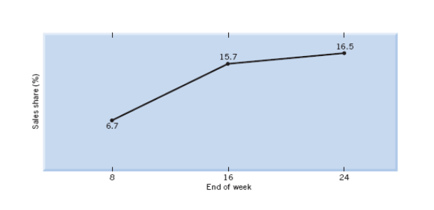

A smooth trend may hide short-lived events.

WEEKLY SCANNER SERVICE

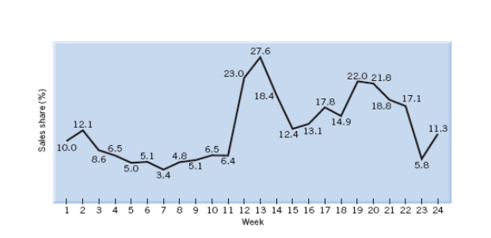

Promotions, shortages, and step changes become visible.

Measure promotion liftForecast new productsTest price and profitImprove assortment and placement

## 4. Single-source systems

01**Recruit a panel**

Identify participating households.

**→**

02**Measure exposure**

Monitor TV programming and commercial exposure.

**→**

03**Link purchases**

Use identification at scanner-equipped stores.

**→**

04**Compare response**

Relate exposure to household purchasing.

Historical source-deck example · Information Resources, Inc. (IRI)

## Benefits and limitations of single-source systems

BENEFITS

- Compare household purchases before and after exposure to different advertising messages
- Obtain test results quickly

LIMITATIONS

- Tracks purchases only at participating scanner-equipped stores
- Cannot confirm whether viewers actively watched or merely left the TV on
- Small test markets may not represent larger markets
- Panel participation can affect behavior

## In-class exercise

RETURN TO YOUR MARKETING PROBLEM OR OPPORTUNITY

Which secondary-data sources could answer useful questions about it?

01

Identify relevant **internal**, **external published**, and **standardized** sources.

02

For each source, specify the insight it could provide.

03

Note one limitation or assumption you would need to manage.

## To sum up

01

Distinguish **primary** from **secondary** research.

02

Evaluate secondary data for **fit, quality, timeliness, and bias**.

03

Use **internal** and **external** sources.

04

Compare **published data** with **standardized sources**.

05

Know what audits, panels, scanners, and single-source systems can—and cannot—tell you.

## Next class

NEXT

**Qualitative and observational methods of primary data collection**

ASSIGNMENT 1 · DUE BEFORE CLASS ON CANVAS

1. Select a firm with a marketing problem you want to study. **(1 point)**
2. Create a 2 × 2 SWOT table with three thoughtful bullets in each cell. **(3 points)**
3. Use the SWOT to state a marketing problem in a few sentences. **(1 point)**